# Flights Analysis Final slides

## RITA Flight Data Exploration

## About this dataset

### This dataset contains a list of 583,985 flights that departed and arrived in the month of January, 2019 with many variables of interest like - departure time, arrival time, flight operator, delay reasons/times (NAS, security, carrier, etc.) and many more.

## 1. What is the best time to board a flight?

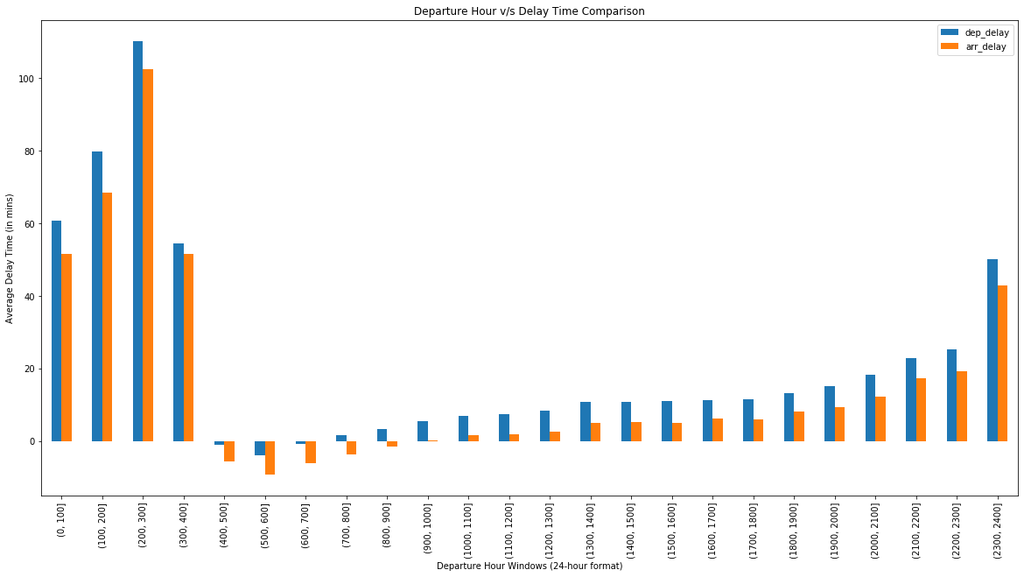

```python
flight_info['dep_hour']=pd.cut(flight_info.dep_time, list(range(0, 2500, 100)))
flight_info.drop(index=flight_info[flight_info.dep_hour.isna()==True].index, inplace=True)
flight_info.groupby('dep_hour').agg({'dep_delay':'mean', 'arr_delay':'mean'}).plot.bar(figsize=(20,10))
plt.xlabel('Departure Hour Windows (24-hour format)')
plt.ylabel('Average Delay Time (in mins)')
plt.title('Departure Hour v/s Delay Time Comparison')
plt.show()
```

## Best time to travel (without any delays) is between 4AM and 9AM. After that, departure and arrival delays increases as the day passes by.

## 2. Considering that a flight is delayed when the arrival time is greater than the scheduled arrival time, what carrier operators have the maximum flights delayed?

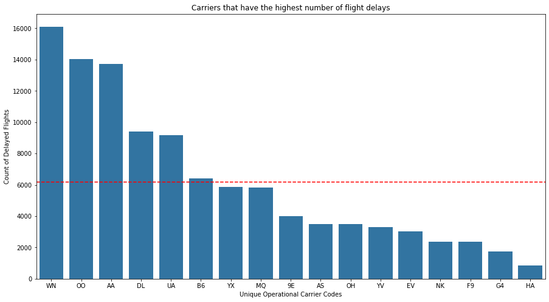

```python
order = flights_delayed.op_unique_carrier.value_counts().index
plt.figure(figsize=(15,8))
sb.countplot(data = flights_delayed, x='op_unique_carrier', order = order, color = sb.color_palette()[0])
plt.xlabel('Unique Operational Carrier Codes')
plt.ylabel('Count of Delayed Flights')
plt.title('Carriers that have the highest number of flight delays')
average_val = round(flights_delayed.count()[0]/flights_delayed.op_unique_carrier.nunique())
plt.axhline(average_val, ls = '--', color="r");
```

## Flight operators listed below have the maximum flights delayed in January, 2019.

### WN - Southwest Airlines

### OO - SkyWest Airlines

### AA - American Airlines

### DL - Delta Airlines

### UA - United Airlines

## 3. Of all delayed flights for the above mentioned operators, what is the most reported reason for the delay?

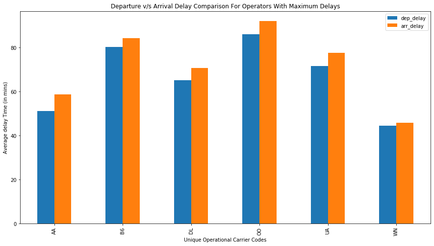

```python
flights_delayed_subset.groupby('op_unique_carrier').agg({'dep_delay':'mean', 'arr_delay':'mean'}).sort_values('op_unique_carrier').plot.bar(figsize=(15,8))
plt.xlabel('Unique Operational Carrier Codes')
plt.ylabel('Average delay Time (in mins)')
plt.title('Departure v/s Arrival Delay Comparison For Operators With Maximum Delays')
```

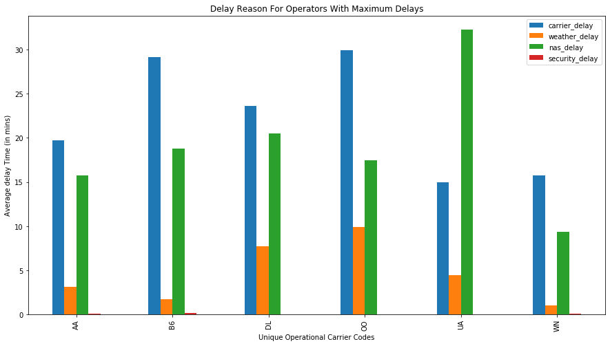

```python
flights_delayed_subset.groupby('op_unique_carrier').agg({'carrier_delay':'mean', 'weather_delay':'mean' , 'nas_delay':'mean', 'security_delay':'mean'}).sort_values('op_unique_carrier').plot.bar(figsize=(15,8))
plt.xlabel('Unique Operational Carrier Codes')
plt.ylabel('Average delay Time (in mins)')
plt.title('Delay Reason For Operators With Maximum Delays')
```

## For all these operators, OO (or Skywest) has the highest average time of departure and arrival delays, which can be attributed to the carrier operations.

## However, all the UA (or United Airlines) flights are majorly delayed because of National Air System operations.

## 4. What is the relationship between departure and arrival delays?

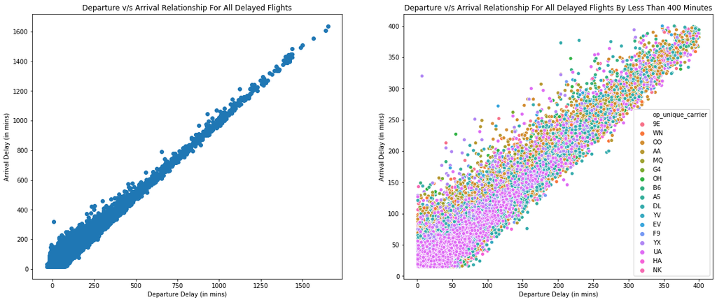

```python
plt.figure(figsize=(20,8))
plt.subplot(1,2,1)
plt.scatter(x=flights_delayed.dep_delay, y=flights_delayed.arr_delay)
plt.xlabel('Departure Delay (in mins)')
plt.ylabel('Arrival Delay (in mins)')
plt.title('Departure v/s Arrival Relationship For All Delayed Flights')
flights_delayed_subset_filtered = flights_delayed.query('dep_delay > 0 and arr_delay > 0 and dep_delay <= 400 and arr_delay <= 400')
plt.subplot(1,2,2)
sb.scatterplot(x=flights_delayed_subset_filtered.dep_delay, y=flights_delayed_subset_filtered.arr_delay, hue=flights_delayed_subset_filtered.op_unique_carrier)
plt.xlabel('Departure Delay (in mins)')
plt.ylabel('Arrival Delay (in mins)')
plt.title('Departure v/s Arrival Relationship For All Delayed Flights By Less Than 400 Minutes')
plt.show()
```

## There seems to be a linear relationship between departure and arrival delay times (as per the plot on the left).

## Using color, however, to identify this relationship broken down by each carrier, in plot 2, is not providing much value.

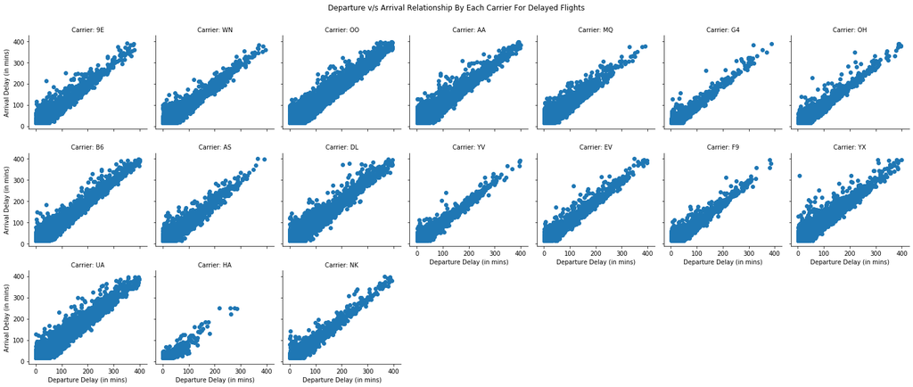

```python
g = sb.FacetGrid(data = flights_delayed_subset_filtered, col = 'op_unique_carrier', col_wrap=7)
g = (g.map(plt.scatter, 'dep_delay', 'arr_delay').set_titles("Carrier: {col_name}"))
g.set_xlabels("Departure Delay (in mins)")
g.set_ylabels("Arrival Delay (in mins)")
plt.subplots_adjust(top=0.9)
g.fig.suptitle('Departure v/s Arrival Relationship By Each Carrier For Delayed Flights');
```

## By using grids, it is clear that all the carriers which have delayed flights in January, 2019 follow a linear relationship between departure and arrival delays. In other words, each delayed departed flight will highly likely be delayed on arrival as well.